# Title: DataViz Assignment4:Exploratory Data Visualizations

Author: Ruochen Qiu Date: 10/15/2017

This report including five charts which illustrated the relationship between Chicago public school ACT test performance and their drop out rate, as well as the distribution of suspect crime which involve in gang activities and 2016 summer Chicago crime analysis.

```r
library(tidyverse)
library(rmarkdown)
library(ggplot2)
library(readr)
library(haven)
library(dplyr)
library(tidyr)
library(stringr)
library(wesanderson)
library(RColorBrewer)
library(ggthemes)
library(plotrix)
library(raster)
library(ggmap)
library(cowplot)
```

## Chart 1: Public School Performance 2012

Data loading and cleaning.

```r
cps <- read_csv("cps1.csv")
cps <- cps %>%
  filter(`Overall Rating` != "Not Enough Data")
```

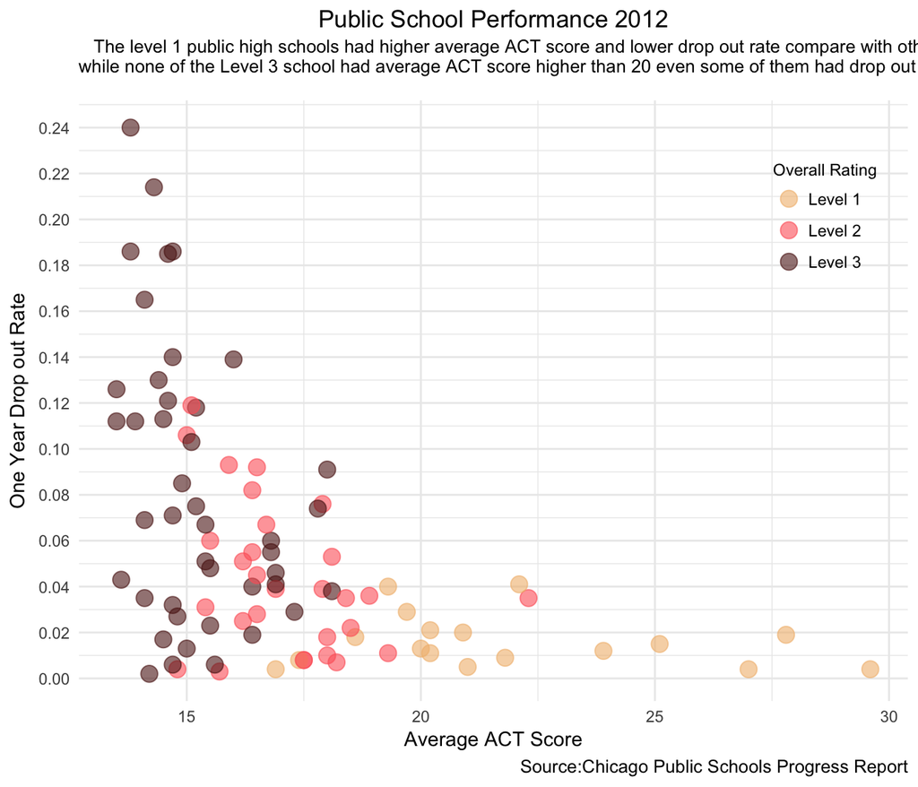

```r
cps_plot <- ggplot(data = cps, aes(x=`Average Score ACT 2012`, y=`One-Year Dropout Rate 2012 - Percent`, color=`Overall Rating`))+geom_point(alpha=0.6, size =4)+
  scale_y_continuous(breaks=seq(0, 0.3, 0.02))+theme_minimal()+
  scale_color_manual(values=wes_palette(n=3, name="GrandBudapest"))+
  theme(legend.title = element_text(size = 9),
        legend.position = c(0.9, 0.8),
        legend.text = element_text(size = 9))+
  labs(title = "Public School Performance 2012",
       subtitle = "   The level 1 public high schools had higher average ACT score and lower drop out rate compare with other two levels,
while none of the Level 3 school had average ACT score higher than 20 even some of them had drop out rate lower than 0.02.
",
       caption = "Source:Chicago Public Schools Progress Report", x = "Average ACT Score", y = "One Year Drop out Rate")+
  theme(plot.title = element_text(hjust = 0.5))
```

## Chart 2: 2016 Chicago Summer Investigatory Stop by Age

Data loading and cleaning.

```r
isr <- read_csv("isr.csv")

isr_lim <- isr %>% subset(DATE >="7/1/16" & DATE <= "8/31/16")
isr_lim <- isr_lim %>%
  filter(AGE <= 90)
isr_lim <- isr_lim %>%
  add_count(AGE)
isr_lim <- isr_lim %>%
  filter(!is.na(`Contact Type`))
```

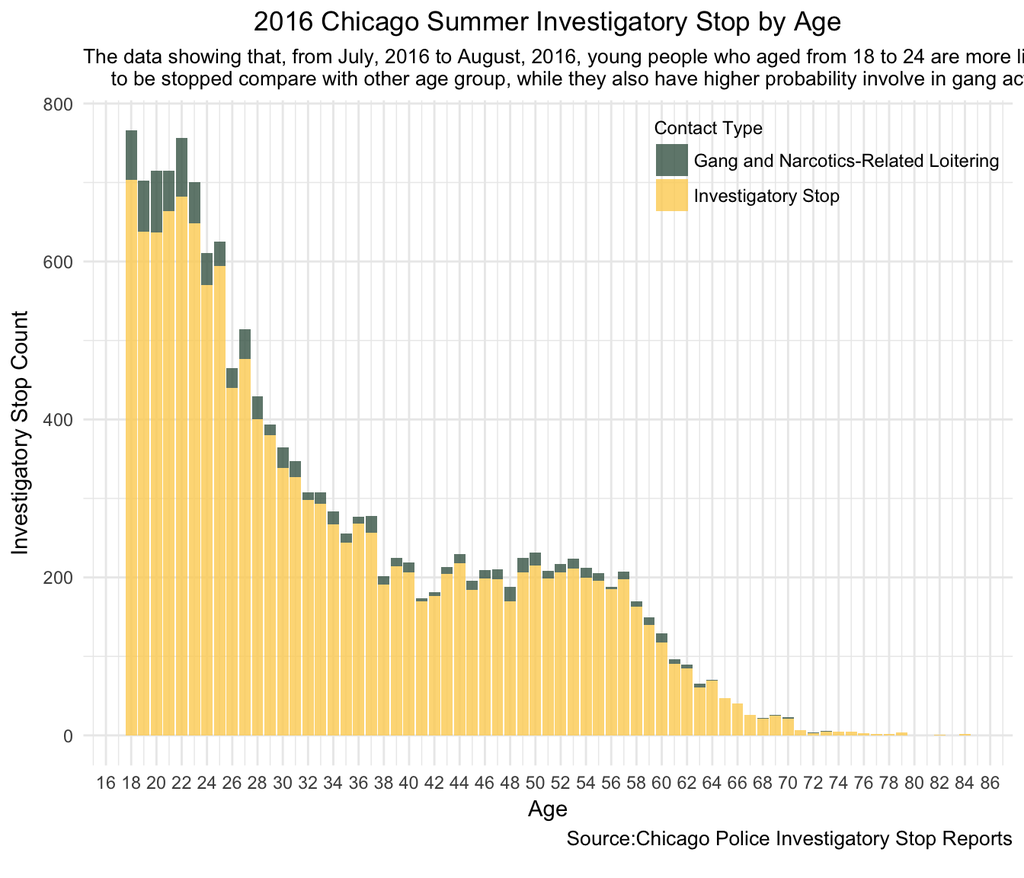

```r
isr_plot <- ggplot(data = isr_lim, aes(x=AGE, fill=`Contact Type`))+geom_bar(alpha=0.8)+
  scale_fill_manual(values = wes_palette("Chevalier"))+
  scale_x_continuous(breaks=seq(16, 90, 2)) + theme_minimal()+
  theme(legend.title = element_text(size = 9),
        legend.position = c(0.8, 0.9),
        legend.text = element_text(size = 9))+
labs(title = "2016 Chicago Summer Investigatory Stop by Age",
     subtitle = "The data showing that, from July, 2016 to August, 2016, young people who aged from 18 to 24 are more likely
     to be stopped compare with other age group, while they also have higher probability involve in gang activities.",
     caption = "Source:Chicago Police Investigatory Stop Reports
     ", x = "Age", y = "Investigatory Stop Count") +
       theme(plot.title = element_text(hjust = 0.5))
```

In this chart, only the investigatory stop data been studied while the legend shows weather the suspects involve in gang activities. It’s pretty obvious that young people aged from 18-24 had higher possibility to be stopped while they also had higher likelihood to involving in **gang activities**.

## Chart 3: 2016 Chicago Crime by Hours

Data loading and cleaning.

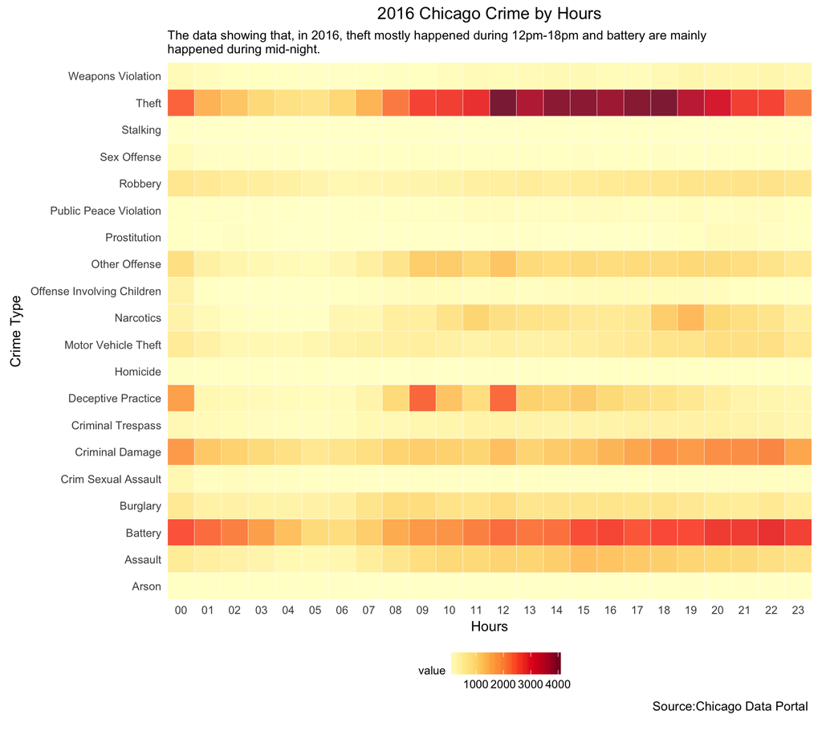

```r
cri_lim <- read_csv("cri_lim_trim.csv")
cri_lim <- arrange(cri_lim,desc(value))

cri_plot<- ggplot(cri_lim, aes(x=Hour, y=`Primary Type`, fill= value)) + geom_tile(colour = "white",alpha=0.9) +
   theme_minimal() +
  scale_fill_gradientn(colours = brewer.pal(9, 'YlOrRd'))+
  scale_x_discrete(expand = c(0, 0)) +
  scale_y_discrete(expand = c(0, 0)) +
  coord_equal() +
  theme(legend.position = "bottom", legend.direction = "horizontal",
              legend.box = "horizontal",
        legend.title = element_text(size = 9),
        legend.text = element_text(size = 9))+
theme(panel.grid.major = element_blank(), panel.grid.minor = element_blank())+
  labs(title = "2016 Chicago Crime by Hours",
       subtitle = "The data showing that, in 2016, theft mostly happened during 12pm-18pm and battery are mainly
happened during mid-night.",
       caption = "Source:Chicago Data Portal
         ", x = "Hours", y = "Crime Type")+
       theme(plot.title = element_text(hjust = 0.5))
```

This chart shows the most frequently appeared crime incidents during 24 hours in the summer of 2016. The dark red color indicating the highest volume while the light yellow shows the lowest volume. From the chart, we can tell that theft had significantly higher incidence rate compare with other crime types and it’s more likely happening **during afternoon**. Battery had a similar tendency while deceptive practice more likely to appear at morning.

## Chart 4: Comparison between Investigation Stop and Crime Offense by District

```r
cri <- read_csv("cri.csv")

cri <- cri %>% subset(Date >="1/1/16" & Date <= "12/31/16")
isr <- isr %>% subset(DATE >="1/1/16" & DATE <= "12/31/16")

cri_n <-cri %>%
  group_by(District) %>%
  summarise(IS = n())

isr_n <- isr %>%
  group_by(DISTRICT) %>%
  summarise(Cr = n())

names(cri_n)[names(cri_n)=="District"] <- "DISTRICT"

cri_n <- cri_n %>%
  filter(!is.na(DISTRICT))
isr_n <- isr_n %>%
  filter(!is.na(DISTRICT))

join <- left_join(cri_n, isr_n, by = "DISTRICT")

Investigation_Stop <- join$IS
Crime <- join$Cr
District <-join$DISTRICT
```

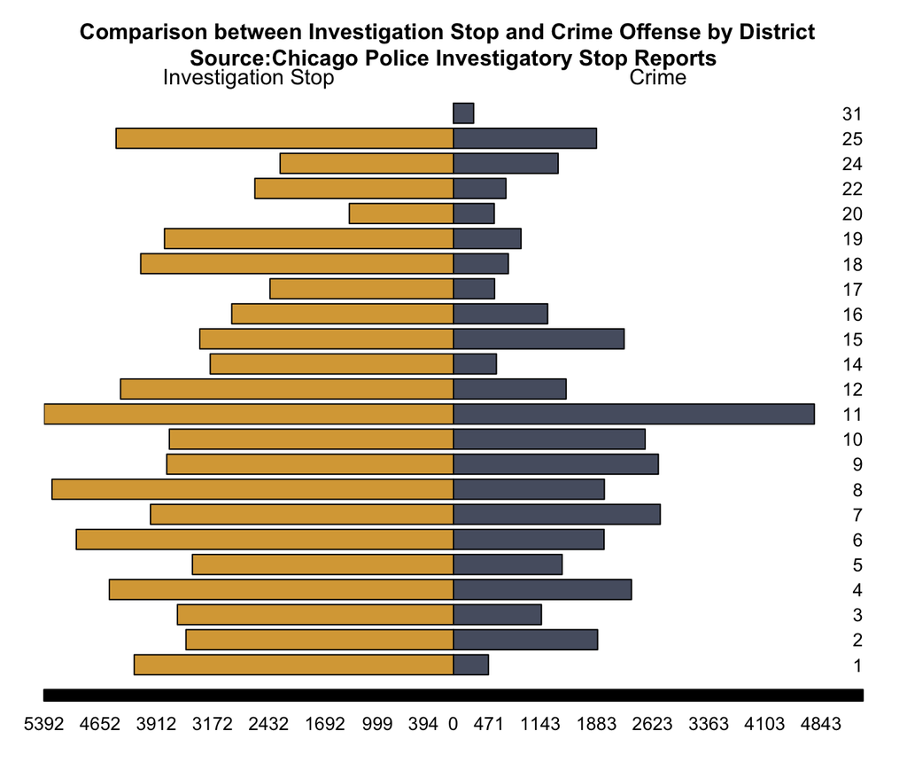

```r
par(cex=0.85,bg="transparent")
par(mar=pyramid.plot(Investigation_Stop, Crime, top.labels=c("Investigation Stop", "",  "Crime"),labels=District,main="Comparison between Investigation Stop and Crime Offense by District
Source:Chicago Police Investigatory Stop Reports", lxcol="#d9a744", rxcol="#575e70", unit="",  gap=0 ))
```

## Chart 5: 2016 Summer Chicago Severe Crime Map

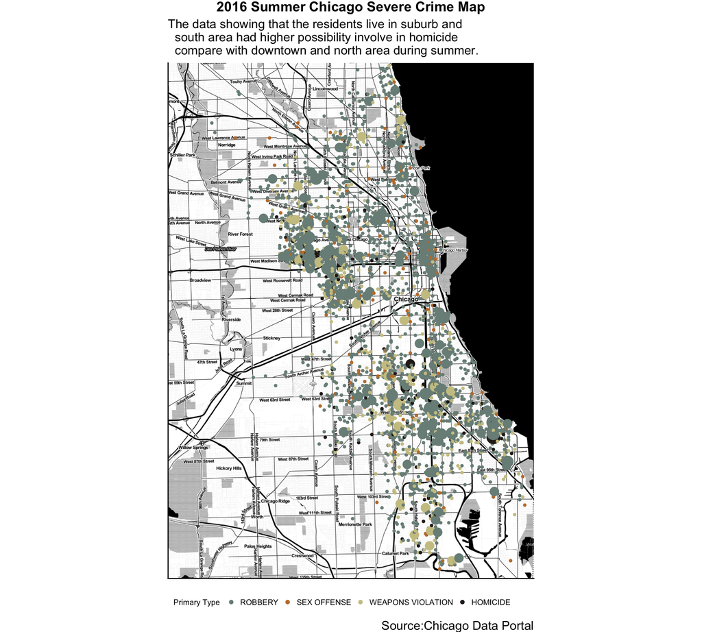

```r
cri_offense<- cri %>% subset(Date >="7/1/16" & Date <= "8/31/16")
cri_offense$Location [cri_offense$Location  == ''] <- NA
cri_offense<- na.omit(cri_offense)

cri_offense$Longitude <- round(as.double(cri_offense$Longitude), 3)
cri_offense$Latitude <- round(as.double(cri_offense$Latitude), 3)

cri_offense <- cri_offense %>%  filter(`Primary Type` =="WEAPONS VIOLATION"|`Primary Type` =="SEX OFFENSE"|`Primary Type` =="ROBBERY"|`Primary Type` =="HOMICIDE")

cri_offense$`Primary Type` <- factor(cri_offense$`Primary Type`, levels = c("ROBBERY","SEX OFFENSE","WEAPONS VIOLATION","HOMICIDE"))

cri_offense<- cri_offense %>%
  group_by(`Longitude`,`Latitude`,`Primary Type`) %>%
  summarise(TOTAL = n())

chicago <- get_stamenmap(bbox = c(left = -87.885169, bottom=41.643919,
                                    right = -87.523984, top = 42.023022),
                             zoom=12,maptype="toner")

chicago <- ggmap(chicago, extent ="device")
map<- chicago+geom_point( data = cri_offense, aes(x = Longitude, y = Latitude, color =`Primary Type`,size=TOTAL), alpha=1)+guides(size=FALSE)+ scale_color_manual(values=wes_palette(n=4, name="Moonrise2")) +
  theme(legend.position = "bottom", legend.direction = "horizontal",
        legend.box = "horizontal",
        legend.title = element_text(size = 8),
        legend.text = element_text(size = 8))+
theme(panel.grid.major = element_blank(), panel.grid.minor = element_blank())+
  labs(title = "2016 Summer Chicago Severe Crime Map",
       subtitle = "The data showing that the residents live in suburb and
  south area had higher possibility involve in homicide
  compare with downtown and north area during summer.",
       caption = "Source:Chicago Data Portal")+
       theme(plot.title = element_text(hjust = 0.5))
```

This map is focus on the severe crime incidents appeared during summer 2016 at Chicago. The point size indicating the frequency of the incidents while the four crime types been denoted with four different colors. It’s easy to tell that robbery and weapons violence are roughly spread around the whole city, while homicide incidents are more likely to appear in **southern** part of the city.